# Stan demo with Spati data

In this notebook, we compare estimating linear mixed-effect models with NLME and Stan. The dataset comes from package “lmfor” and the example is the same that is used in mixed-effect model courses.

# Preparing the data

```r
library(lmfor)
data(spati)
# inlude only observations with measured growth
spati<-spati[spati$id2>0,]
spati$plot <- with(spati,factor(plot))
```

# Estimation with NLME

The model estimates future tree growth based on its past growth. The tree measurements come from different plots that may have different growing conditions. The model assumes that the observations within one plot may be correlated with each other.

```r
library(nlme)
spati_lme <- lme(id1~id2,random=~id2|plot,data=spati)
summary(spati_lme)
```

```
Linear mixed-effects model fit by REML
 Data: spati
       AIC     BIC    logLik
  26314.71 26353.5 -13151.36

Random effects:
 Formula: ~id2 | plot
 Structure: General positive-definite, Log-Cholesky parametrization
            StdDev   Corr
(Intercept) 5.622427 (Intr)
id2         0.173359 -0.578
Residual    3.710059

Fixed effects: id1 ~ id2
                Value Std.Error   DF   t-value p-value
(Intercept) 1.8973172 0.7536626 4687  2.517462  0.0119
id2         0.8059964 0.0256477 4687 31.425648  0.0000
 Correlation:
    (Intr)
id2 -0.591

Standardized Within-Group Residuals:
        Min          Q1         Med          Q3         Max
-5.62386155 -0.46624008 -0.05002616  0.43340772 10.06902382

Number of Observations: 4747
Number of Groups: 59
```

# BRMS-package

Bayesian Regression Models with Stan (BRMS) uses Stan underneath, but offers lme4-like syntax for specifying the model

```r
spati_brm
```

```
 Family: gaussian
  Links: mu = identity; sigma = identity
Formula: id1 ~ id2 + (1 + id2 | plot)
   Data: spati (Number of observations: 4747)
Samples: 4 chains, each with iter = 2000; warmup = 1000; thin = 1;
         total post-warmup samples = 4000

Group-Level Effects:
~plot (Number of levels: 59)
                   Estimate Est.Error l-95% CI u-95% CI Eff.Sample Rhat
sd(Intercept)          5.75      0.57     4.75     6.97       1343 1.00
sd(id2)                0.18      0.02     0.14     0.22       1502 1.00
cor(Intercept,id2)    -0.56      0.09    -0.72    -0.36       1627 1.00

Population-Level Effects:
          Estimate Est.Error l-95% CI u-95% CI Eff.Sample Rhat
Intercept     1.89      0.77     0.36     3.38        427 1.00
id2           0.81      0.03     0.75     0.86        905 1.00

Family Specific Parameters:
      Estimate Est.Error l-95% CI u-95% CI Eff.Sample Rhat
sigma     3.71      0.04     3.64     3.79       4000 1.00

Samples were drawn using sampling(NUTS). For each parameter, Eff.Sample
is a crude measure of effective sample size, and Rhat is the potential
scale reduction factor on split chains (at convergence, Rhat = 1).
```

In comparison to the LME estimation, all the parameters have now posterior densities instead of point estimates. The BRM estimatation (0.81) of id2 coefficient matches the LME estimation, but now we can inspect its accuracy from the posterior.

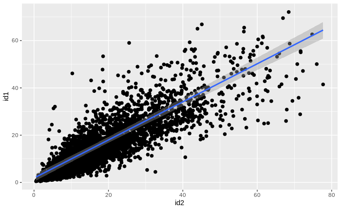

You can also inspect easily the marginal effect between past and future growth

```r
plot(marginal_effects(spati_brm), points = TRUE)
```

BRMS generates Stan-code for the spesified regression model, and the generated code can be inspected with “stancode” method

```r
#stancode(spati_brm)
```

# RSTAN - Custom Stan-models

```r
library(rstan)

modelfile <- "spati_stan.rds"
if (file.exists(modelfile))
{
  spati_stan <- readRDS(modelfile)
} else {

  rstan_options(auto_write=TRUE)
  options(mc.cores=parallel::detectCores())

  # Parameters are feeded to Stan model as a list of values
  params <- within(list(),
                 {
                   N <- nrow(spati)
                   Y <- as.vector(spati$id1)
                   X <- cbind(1,as.matrix(spati$id2))
                   Z <- X                               # Z is indexed by 'group' so it's not block diagonal matrix
                   p <- 2                               # fixed-effects
                   k <- 2                               # random-effects
                   J <- length(levels(spati$plot))
                   group <- as.integer(spati$plot)      # group index for data rows
                 })

  spati_stan <- stan(file="spati.stan", data=params, warmup=1000, iter=2000, chains=4, control = list(adapt_delta = 0.80))

  saveRDS(spati_stan, file=modelfile)
}
```

Let’s make a sanity check that the Bayesian estimates are close to the LME estimates

```r
print(spati_stan, pars = c("beta[1]", "beta_Intercept", "sigma_e", "sigma_b[1]", "sigma_b[2]"))
```

[output not shown]

Instead of HMC sampling, Stan allows you to estimate the model with variational bayes algorithm that is significantly faster (but approximate)

```r
spati_model <- stan_model(file = "spati.stan")
spati_vb <- vb(spati_model, data=params, output_samples=3000, iter=4000, seed=123)

print(spati_vb, pars = c("beta[1]", "beta_Intercept", "sigma_e", "sigma_b[1]", "sigma_b[2]"))
```

[output not shown]

# Posterior predictive check

Our custom Stan-code generates also a posterior predictive density where the in-sample values are feeded to the estimated model. If the model is accurate, it should generate a closely matching density with the original target values.

```r
library(bayesplot)

posterior <- extract(spati_stan, pars = c("Y_rep"))
posterior_y_50 <- posterior$Y_rep[1:50,]

plot(ppc_dens_overlay(params$Y, posterior_y_50) +
       coord_cartesian(xlim = c(-1, 50)))
```

[output not shown]